# GE 509 Preliminary Analysis

## Pat Sorensen, Nov 20th

Forests in the northeastern U.S. are projected to experience a reduction in the depth and duration of snow cover during the next century. Because snow insulates soils from freezing air, soils are expected to experience colder winter temperatures and an increased number of freeze - thaw events. Soil microbes are likely to be directly affected by the physiological stress and disruption of soil aggregates associated with soil freezing. Also, co-occurring root mortality caused by increased soil freezing could indirectly effect microbial biomass and activity due to winter climate induced changes in plant-microbe interactions. We are taking advantage of a natural winter climate gradient occurring at Hubbard Brook Experimental Forest in an attempt to isolate direct winter climate effects on microbes from winter climate change effects on microbes that arise due to co-occuring winter climate effects on plant roots.

The goal is to estimate root biomass and production, enzyme activity, and net N mineralization from the soils collected from across the natural winter gradient. I am thinking about this dataset as a generalized mixed effects problem  the fixed effects I am interested in are core type, harvest date, and the continuous covariates measured at each site which include winter snow and soil frost depth and duration, minimum winter soil temperature, and soil temperature or volumetric moisture content at the time of soil sampling. The random effects are sites, plots, litter-boxes, and duplicate cores. The objectives I am addressing are (1) to determine whether root production differs across the gradient (2) whether microbial biomass, enzyme activity, or net N mineralization rates differ by core type or as a function of winter snow / frost depth, volumetric water content, or soil temperature at the time of sampling (3) to use model selection to determine the most parsimonious models of root production, microbial enzyme activity, and net N mineralization from across the winter climate gradient.

## Objective 1 - Root Biomass Data Analysis

Root biomass was determined by root-picking all roots in ingrowth and exclusion cores on all dates (July 2012, October 2012, October 2013). The questions that I want to determine from the root biomass data set is (1) whether root biomass is greater in the ingrowth versus the exclusion cores (2) if root production is related to winter climate (3) if the difference changes by soil horizon, over sampling dates

```r
root.wcs<-read.csv(file="C:/Users/Patrick Sorensen/Documents/Winter Climate Gradient/Data/Winter_Climate_Gradient_Root_Biomass.csv", header=T) ##loading root biomass data

str(root.wcs) ##make sure all the variables are coded correctly
```

```
## 'data.frame':    432 obs. of  28 variables:
##  $ Core_Master_ID                    : int  1 2 3 4 5 6 7 8 9 10 ...
##  $ Elevation                         : Factor w/ 2 levels "High","Low": 1 1 1 1 1 1 1 1 1 1 ...
##  $ Site                              : Factor w/ 6 levels "H1","H2","H3",..: 1 1 1 1 1 1 2 2 2 2 ...
##  $ Plot                              : int  1 1 2 2 3 3 1 1 2 2 ...
##  $ Litter_box                        : int  4 4 4 4 4 4 4 4 4 4 ...
##  $ Rep_.A.or.B.                      : Factor w/ 2 levels "A","B": 1 2 1 2 1 2 1 2 1 2 ...
##  $ Core_Type                         : Factor w/ 2 levels "50um Exclusion",..: 2 2 2 2 2 2 2 2 2 2 ...
##  $ Elevation.1                       : int  539 539 539 539 539 539 555 555 555 555 ...
##  $ Harvest                           : Factor w/ 3 levels "July_2012","Oct_2012",..: 1 1 1 1 1 1 1 1 1 1 ...
##  $ Harvest_Date                      : Factor w/ 3 levels "15-Oct-12","41561",..: 3 3 3 3 3 3 3 3 3 3 ...
##  $ Soil_Type                         : Factor w/ 2 levels "Mineral","Organic": 2 2 2 2 2 2 2 2 2 2 ...
##  $ Installation_Date                 : int  40689 40689 40689 40689 40689 40689 40689 40689 40689 40689 ...
##  $ Years_Since_Installed             : num  1.12 1.12 1.12 1.12 1.12 ...
##  $ Coin_Envelope_Mass_g              : num  3.87 3.84 3.86 3.87 3.89 3.93 3.92 3.9 3.88 3.93 ...
##  $ Coin_envelope_plus_Root_dry_mass_g: num  3.99 3.99 3.99 4 3.96 3.9 4.1 4.06 3.94 3.92 ...
##  $ Root_dry_mass_g                   : num  0.12 0.15 0.13 0.13 0.07 0 0.18 0.16 0.06 0 ...
##  $ Root_Production_g_yr.1            : num  0.1071 0.1339 0.116 0.116 0.0625 ...
##  $ Mean_30_Day_VWC                   : num  0.374 0.374 0.374 0.374 0.374 ...
##  $ Mean_30_Day_Temperature           : num  12.9 12.9 12.9 12.9 12.9 ...
##  $ Mean_10_Day_VWC                   : num  0.333 0.333 0.333 0.333 0.333 ...
##  $ Mean_10_Day_Temperature           : num  15.2 15.2 15.2 15.2 15.2 ...
##  $ Day_of_Sampling_Mean_VWC          : num  0.312 0.312 0.312 0.312 0.312 ...
##  $ Day_of_Sampling_Temperature       : num  15.8 15.8 15.8 15.8 15.8 ...
##  $ Minimum_Winter_Soil_Temperature   : num  0.55 0.55 0.55 0.55 0.55 0.55 -0.15 -0.15 -0.15 -0.15 ...
##  $ Maximum_Frost_Depth               : num  3.33 3.33 3.33 3.33 3.33 3.33 5 5 5 5 ...
##  $ Cumulative_Frost_Depth            : num  12.3 12.3 12.3 12.3 12.3 ...
##  $ Frost_Depth_auc                   : num  164 164 164 164 164 ...
##  $ Snow_Depth_AUC                    : num  2383 2383 2383 2383 2383 ...
```

```r
summary(root.wcs) ##print summary statistics for root data
```

```
##  Core_Master_ID  Elevation  Site         Plot     Litter_box
##  Min.   :  1.0   High:216   H1:72   Min.   :1   Min.   :4.00
##  1st Qu.: 54.8   Low :216   H2:72   1st Qu.:1   1st Qu.:4.00
##  Median :120.5              H3:72   Median :2   Median :4.00
##  Mean   :120.5              L1:72   Mean   :2   Mean   :4.33
##  3rd Qu.:186.2              L2:72   3rd Qu.:3   3rd Qu.:5.00
##  Max.   :240.0              L3:72   Max.   :3   Max.   :5.00
##
##  Rep_.A.or.B.          Core_Type    Elevation.1       Harvest
##  A:216        50um Exclusion:216   Min.   :375   July_2012:144
##  B:216        Ingrowth      :216   1st Qu.:401   Oct_2012 :144
##                                    Median :525   Oct_2013 :144
##                                    Mean   :496
##                                    3rd Qu.:555
##                                    Max.   :595
##
##     Harvest_Date   Soil_Type   Installation_Date Years_Since_Installed
##  15-Oct-12:144   Mineral:216   Min.   :40688     Min.   :1.12
##  41561    :144   Organic:216   1st Qu.:40689     1st Qu.:1.12
##  8-Jul-12 :144                 Median :40690     Median :1.39
##                                Mean   :40689     Mean   :1.63
##                                3rd Qu.:40690     3rd Qu.:2.39
##                                Max.   :40690     Max.   :2.39
##
##  Coin_Envelope_Mass_g Coin_envelope_plus_Root_dry_mass_g Root_dry_mass_g
##  Min.   :3.60         Min.   :3.62                       Min.   :0.000
##  1st Qu.:3.68         1st Qu.:3.75                       1st Qu.:0.000
##  Median :3.71         Median :3.88                       Median :0.080
##  Mean   :3.77         Mean   :3.91                       Mean   :0.161
##  3rd Qu.:3.90         3rd Qu.:4.00                       3rd Qu.:0.240
##  Max.   :4.00         Max.   :6.55                       Max.   :2.860
##  NA's   :1            NA's   :20
##  Root_Production_g_yr.1 Mean_30_Day_VWC Mean_30_Day_Temperature
##  Min.   :0.0000         Min.   :0.247   Min.   :12.8
##  1st Qu.:0.0000         1st Qu.:0.284   1st Qu.:13.5
##  Median :0.0504         Median :0.312   Median :13.9
##  Mean   :0.0964         Mean   :0.318   Mean   :13.9
##  3rd Qu.:0.1426         3rd Qu.:0.332   3rd Qu.:14.4
##  Max.   :2.0590         Max.   :0.454   Max.   :14.6
##
```

[output cut: 9 more lines]

```
##  Min.   : 9.28               Min.   :-1.650
##  1st Qu.: 9.92               1st Qu.:-0.700
##  Median :11.99               Median :-0.150
##  Mean   :12.74               Mean   :-0.269
##  3rd Qu.:15.83               3rd Qu.: 0.100
##  Max.   :17.56               Max.   : 0.800
##
##  Maximum_Frost_Depth Cumulative_Frost_Depth Frost_Depth_auc Snow_Depth_AUC
##  Min.   : 0.00       Min.   : 0.00          Min.   :  0.0   Min.   : 724
##  1st Qu.: 1.16       1st Qu.: 1.59          1st Qu.: 22.4   1st Qu.:1306
##  Median : 4.67       Median :13.67          Median :169.3   Median :2331
##  Mean   : 3.63       Mean   :14.62          Mean   :196.7   Mean   :2222
##  3rd Qu.: 5.00       3rd Qu.:25.12          3rd Qu.:323.0   3rd Qu.:2480
##  Max.   :13.67       Max.   :36.00          Max.   :513.2   Max.   :4489
##
```

Before doing any statistical analyses I made some exploratory plots to visualize the data.

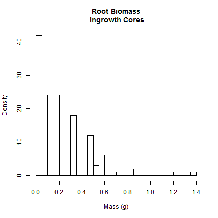

```r
hist(root.wcs$Root_dry_mass_g[which(root.wcs$Core_Type=="Ingrowth")],
     breaks=30,
     main = "Root Biomass\n Ingrowth Cores",
     xlab = "Mass (g)",
     ylab = "Density")
```

The histogram shows that data is centered at low root biomass and skewed to the right. There were many cores that had zero root biomass. I think it is most appropriate to say the root biomass data follows an exponential data distribution.

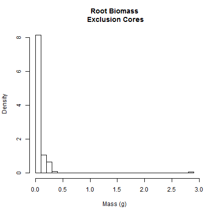

```r
hist(root.wcs$Root_dry_mass_g[which(root.wcs$Core_Type=="50um Exclusion")],
     breaks=30, freq=FALSE,
     main = "Root Biomass\n Exclusion Cores",
     xlab = "Mass (g)",
     ylab = "Density")
```

In a perfect world there would be no root biomass in the exclusion cores. However, some of the exclusion cores failed and ended up having roots within the core

Because the ingrowth and exclusion cores started out root-free when they were installed in the field in May 2011, I expected the ingrowth cores to become more 'rooty' at each subsequent harvest date (July 2012, October 2012, October 2013)